# learningAnalysis_07_29

## cueDiff: signed difference between reported - true

```r
df_cueDiffs <- df_est %>% group_by(subID, trueCue) %>% summarise(meanDiff = mean(cueDiff, na.rm=T))
```

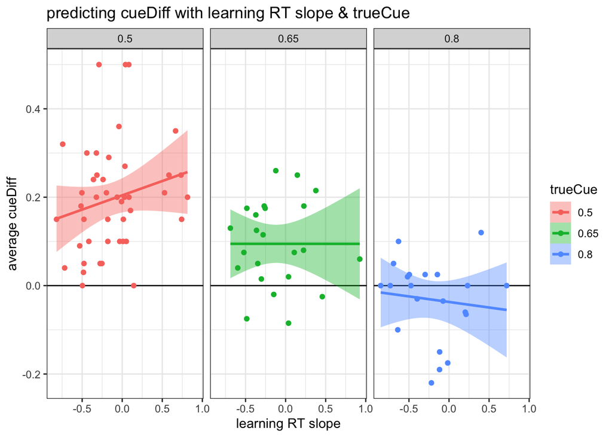

```r
# make a plot
df_cueDiffs %>% left_join(., df_trueCue_trends, by=c('subID', 'trueCue')) %>%
  mutate(trueCue = factor(trueCue, levels=c(0.5, 0.65, 0.8))) %>%
  ggplot(., aes(x=scaledLogTrial.trend, y=meanDiff, color=trueCue, fill=trueCue)) + facet_wrap(~trueCue) + geom_hline(yintercept=0) +
  theme_bw() + geom_point() + stat_smooth(method = 'lm') + labs(y = 'average cueDiff', x = 'learning RT slope', title='predicting cueDiff with learning RT slope & trueCue')
```

```r
# fit a linear model
df_cueDiffs %>% left_join(., df_trueCue_trends, by=c('subID', 'trueCue')) %>%
  lm(meanDiff ~ scaledLogTrial.trend*trueCue, .) %>% summary()
```

```
##
## Call:
## lm(formula = meanDiff ~ scaledLogTrial.trend * trueCue, data = .)
##
## Residuals:
##       Min        1Q    Median        3Q       Max
## -0.215042 -0.081712 -0.004059  0.057062  0.311334
##
## Coefficients:
##                              Estimate Std. Error t value Pr(>|t|)
## (Intercept)                   0.60459    0.06385   9.469 6.76e-15 ***
## scaledLogTrial.trend          0.21128    0.14716   1.436    0.155
## trueCue                      -0.79660    0.10384  -7.671 2.75e-11 ***
## scaledLogTrial.trend:trueCue -0.30088    0.23559  -1.277    0.205
## ---
## Signif. codes:  0 '***' 0.001 '**' 0.01 '*' 0.05 '.' 0.1 ' ' 1
##
## Residual standard error: 0.1091 on 84 degrees of freedom
## Multiple R-squared:  0.438,  Adjusted R-squared:  0.418
## F-statistic: 21.82 on 3 and 84 DF,  p-value: 1.525e-10
```

## subjectiveCue: explicitly reported cue probability

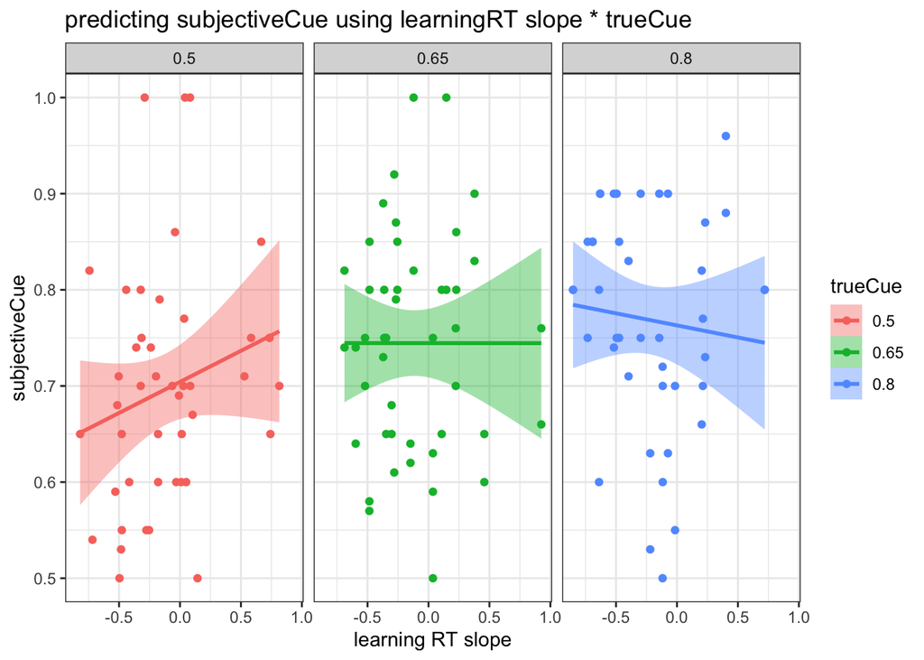

```r
# plot
df_est %>% left_join(., df_trueCue_trends, by=c('subID', 'trueCue')) %>%
  mutate(trueCue = factor(trueCue, levels=c(0.5, 0.65, 0.8))) %>%
  ggplot(., aes(x=scaledLogTrial.trend, y=subjectiveCue, color=trueCue, fill=trueCue)) + facet_wrap(~trueCue) +
  theme_bw() + geom_point() + stat_smooth(method = 'lm') + labs(y = 'subjectiveCue', x = 'learning RT slope', title='predicting subjectiveCue using learningRT slope * trueCue')
```

```r
# fit linear model
df_est %>% left_join(., df_trueCue_trends, by=c('subID', 'trueCue')) %>%
  lm(subjectiveCue ~ scaledLogTrial.trend*trueCue, .) %>% summary()
```

```
##
## Call:
## lm(formula = subjectiveCue ~ scaledLogTrial.trend * trueCue,
##     data = .)
##
## Residuals:
##       Min        1Q    Median        3Q       Max
## -0.270371 -0.087761  0.004995  0.068123  0.308724
##
## Coefficients:
##                              Estimate Std. Error t value Pr(>|t|)
## (Intercept)                   0.60977    0.05935  10.274   <2e-16 ***
## scaledLogTrial.trend          0.20236    0.13774   1.469   0.1442
## trueCue                       0.19647    0.09124   2.153   0.0332 *
## scaledLogTrial.trend:trueCue -0.28925    0.20823  -1.389   0.1672
## ---
## Signif. codes:  0 '***' 0.001 '**' 0.01 '*' 0.05 '.' 0.1 ' ' 1
##
## Residual standard error: 0.1164 on 128 degrees of freedom
## Multiple R-squared:  0.07588,    Adjusted R-squared:  0.05422
## F-statistic: 3.503 on 3 and 128 DF,  p-value: 0.01741
```

```r
# compute correlation
df_est %>% left_join(., df_trueCue_trends, by=c('subID', 'trueCue')) %>%
  select(scaledLogTrial.trend, trueCue, subjectiveCue) %>%
  group_by(trueCue) %>%
  summarise(linear_corr = cor(scaledLogTrial.trend, subjectiveCue, method='pearson'),
            nonlinear_corr = cor(scaledLogTrial.trend, subjectiveCue, method='spearman'))
```

```
## # A tibble: 3 × 3
##   trueCue linear_corr nonlinear_corr
##     <dbl>       <dbl>          <dbl>
## 1    0.5     0.211            0.237
## 2    0.65   -0.000142         0.0926
## 3    0.8    -0.0906          -0.161
```

## cueConfidence: confidence in subjectiveCue report

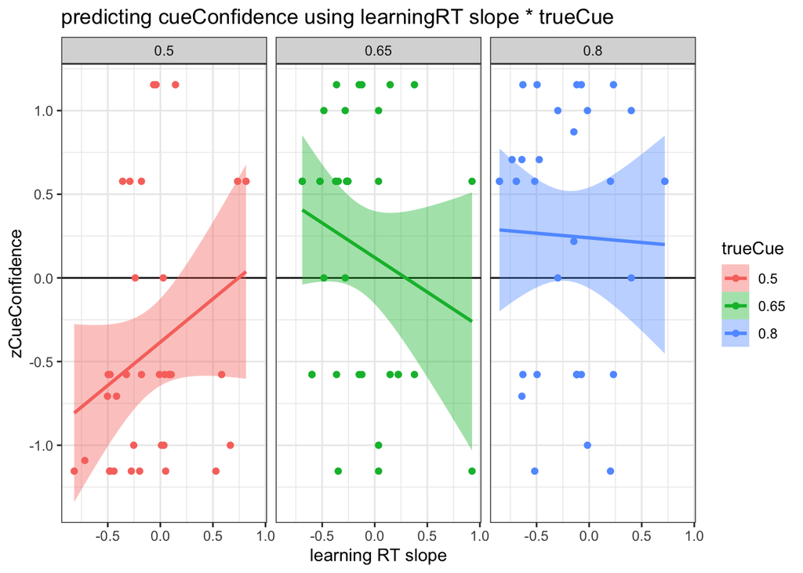

```r
# plot
df_est %>% left_join(., df_trueCue_trends, by=c('subID', 'trueCue')) %>%
  mutate(trueCue = factor(trueCue, levels=c(0.5, 0.65, 0.8))) %>%
  ggplot(., aes(x=scaledLogTrial.trend, y=zCueConf, color=trueCue, fill=trueCue)) + geom_hline(yintercept = 0) +
  facet_wrap(~trueCue) +
  theme_bw() + geom_point() + stat_smooth(method = 'lm') + labs(y = 'zCueConfidence', x = 'learning RT slope', title = 'predicting cueConfidence using learningRT slope * trueCue')
```

```r
# fit linear model
df_est %>% left_join(., df_trueCue_trends, by=c('subID', 'trueCue')) %>%
  lm(zCueConf ~ scaledLogTrial.trend*trueCue, .) %>% summary()
```

```
##
## Call:
## lm(formula = zCueConf ~ scaledLogTrial.trend * trueCue, data = .)
##
## Residuals:
##      Min       1Q   Median       3Q      Max
## -1.57056 -0.62241  0.00949  0.59330  1.48206
##
## Coefficients:
##                              Estimate Std. Error t value Pr(>|t|)
## (Intercept)                   -1.3389     0.4334  -3.089  0.00259 **
## scaledLogTrial.trend           1.0585     1.0137   1.044  0.29892
## trueCue                        2.0569     0.6653   3.092  0.00257 **
## scaledLogTrial.trend:trueCue  -1.5869     1.5172  -1.046  0.29810
## ---
## Signif. codes:  0 '***' 0.001 '**' 0.01 '*' 0.05 '.' 0.1 ' ' 1
##
## Residual standard error: 0.772 on 101 degrees of freedom
##   (27 observations deleted due to missingness)
## Multiple R-squared:  0.1276, Adjusted R-squared:  0.1017
## F-statistic: 4.926 on 3 and 101 DF,  p-value: 0.003105
```

```r
# compute correlation
df_est %>% left_join(., df_trueCue_trends, by=c('subID', 'trueCue')) %>%
  select(scaledLogTrial.trend, trueCue, zCueConf) %>%
  group_by(trueCue) %>%
  summarise(linear_corr = cor(scaledLogTrial.trend, zCueConf, method='pearson', use='na.or.complete'),
            nonlinear_corr = cor(scaledLogTrial.trend, zCueConf, method='spearman', use='na.or.complete'))
```

```
## # A tibble: 3 × 3
##   trueCue linear_corr nonlinear_corr
##     <dbl>       <dbl>          <dbl>
## 1    0.5       0.273          0.311
## 2    0.65     -0.209         -0.112
## 3    0.8      -0.0315         0.0595
```

# effects of learning RT slopes on behavior during inference

## effects on RTs independent of accuracy

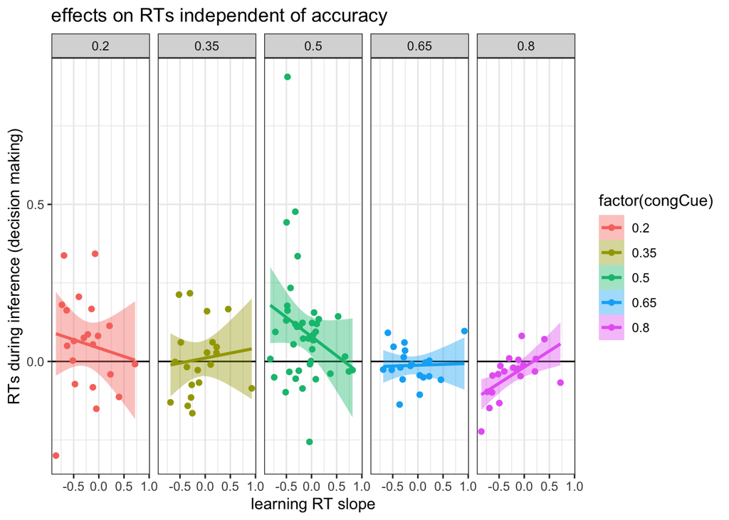

```r
# make plot
df_inf %>%
  group_by(subID, congCue, trueCue, trueCongruence) %>%
  summarise(meanRT = mean(zlogRT, na.rm=T)) %>%
  left_join(., df_trueCue_trends, by=c('subID', 'trueCue')) %>%
  mutate(trueCue = factor(trueCue, levels=c(0.5, 0.65, 0.8))) %>%
  ggplot(., aes(x=scaledLogTrial.trend, y=meanRT, color=factor(congCue), fill=factor(congCue))) + geom_hline(yintercept = 0) +
  facet_grid(~congCue) +
  theme_bw() + geom_point() + stat_smooth(method = 'lm') + labs(y = 'RTs during inference (decision making)', x = 'learning RT slope', title = 'effects on RTs independent of accuracy')
```

```r
# fit & plot linear model
# df_inf %>% left_join(., df_trueCue_trends, by=c('subID', 'trueCue')) %>%
#   lm(zlogRT ~ scaledLogTrial.trend*congCue, .) %>% #summary()
#   emmip(., ~ scaledLogTrial.trend | congCue, var='congCue', CIs=T,
#         at=list(scaledLogTrial.trend=range(df_trueCue_trends$scaledLogTrial.trend),
#                                                                     congCue = c(0.2, 0.5, 0.8)))
# # emtrends for linear model
# df_inf %>% left_join(., df_trueCue_trends, by=c('subID', 'trueCue')) %>%
#   lm(zlogRT ~ scaledLogTrial.trend*congCue, .) %>%
#   emtrends(eff ~ scaledLogTrial.trend, var = 'congCue',
#            at=list(scaledLogTrial.trend=range(df_trueCue_trends$scaledLogTrial.trend),
#                    congCue=c(0.8)))
```

- x-axis: slope of regression line for RTs during learning –> implicit measure of statistical learning
- y-axis: each subject’s average RT during *inference* –> 0 represents the mean across all participants in that condition
- panels: prediction on that trial, ranging from strongly incongruent (congCue==0.2) to strongly congruent(congCue==0.8). neutral cue (makes no real prediction) in the middle (congCue == 0.5)

interpretation (panel by panel): - on strong incongruent trials: subjects who got faster at responding during learning (x < 0) made *slower* responses during decision making. - on weak incongruent trials: there does not appear to be a strong/meaningful relationship between learning RTs & decision RTs. - on “neutral” trials: subjects who were faster at responding to the cue during learning (x < 0) were significantly slower to make responses *when this cue was presented* during decision making - on strong congruent trials: subjects who got faster at responding during learning (x < 0) made *faster* responses, whereas subjects who got slower at responding during learning made *slower* responses during decision making

## inference RTs split up by accuracy

[output not shown]

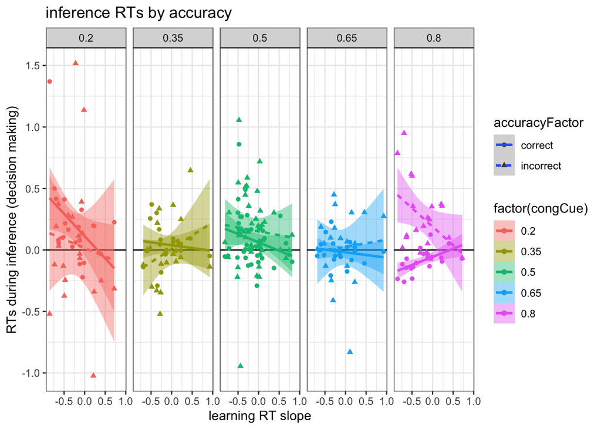

```r
df_inf %>%
  mutate(accuracyFactor = factor(accuracy, levels=c(1,0), labels=c('correct', 'incorrect'))) %>%
  group_by(subID, congCue, trueCue, trueCongruence, accuracyFactor) %>%
  summarise(meanRT = mean(zlogRT, na.rm=T)) %>%
  left_join(., df_trueCue_trends, by=c('subID', 'trueCue')) %>%
  mutate(trueCue = factor(trueCue, levels=c(0.5, 0.65, 0.8))) %>%
  ggplot(., aes(x=scaledLogTrial.trend, y=meanRT, color=factor(congCue), fill=factor(congCue))) + geom_hline(yintercept = 0) +
  facet_grid(~congCue) +
  theme_bw() + geom_point(aes(shape=accuracyFactor)) + stat_smooth(aes(linetype=accuracyFactor), method = 'lm') + labs(y = 'RTs during inference (decision making)', x = 'learning RT slope', title = 'inference RTs by accuracy')
```

they appear to also be present at some levels of congCue here! specifically: - there is a strong interaction with accuracy for strong congruent trials - there is no effect of accuracy on the previously-observed trend for true neutral trials

## how accuracy, scaledLogTrial.trend, and congCue interact to shape zconfidence ratings

[output not shown]

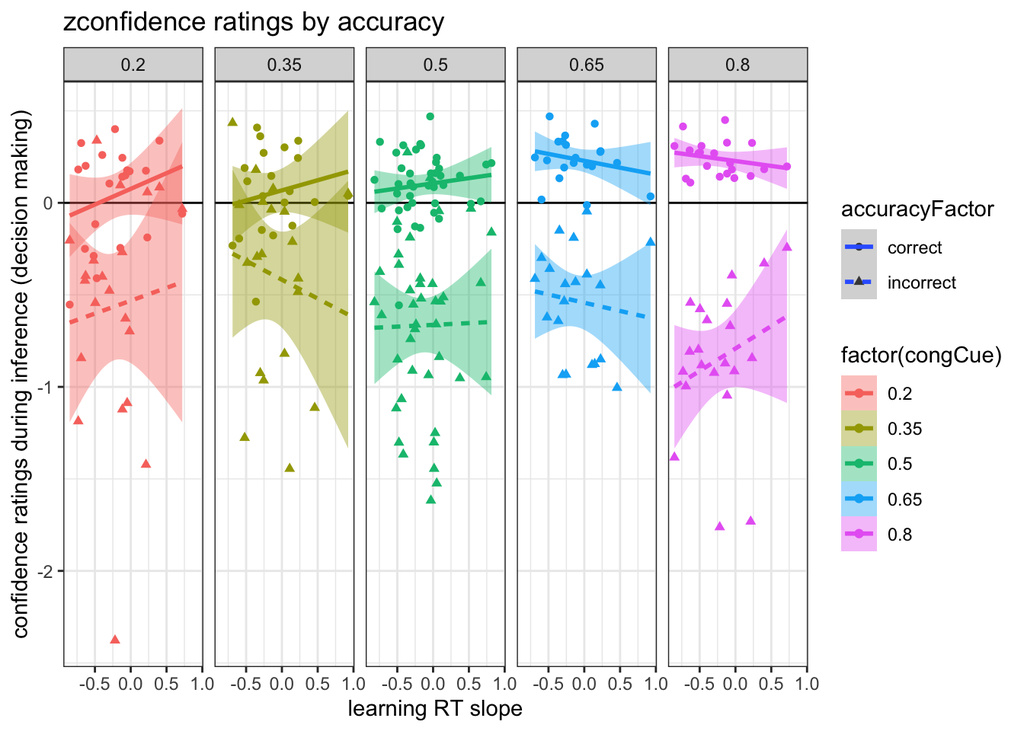

```r
df_inf %>%
  mutate(accuracyFactor = factor(accuracy, levels=c(1,0), labels=c('correct', 'incorrect'))) %>%
  group_by(subID, congCue, trueCue, trueCongruence, accuracyFactor) %>%
  summarise(meanRate = mean(zconf, na.rm=T)) %>%
  left_join(., df_trueCue_trends, by=c('subID', 'trueCue')) %>%
  mutate(trueCue = factor(trueCue, levels=c(0.5, 0.65, 0.8))) %>%
  ggplot(., aes(x=scaledLogTrial.trend, y=meanRate, color=factor(congCue), fill=factor(congCue))) + geom_hline(yintercept = 0) +
  facet_grid(~congCue) +
  theme_bw() + geom_point(aes(shape=accuracyFactor)) + stat_smooth(aes(linetype=accuracyFactor), method = 'lm') + labs(y = 'confidence ratings during inference (decision making)', x = 'learning RT slope', title = 'zconfidence ratings by accuracy')
```

## how accuracy, scaledLogTrial.trend, and congCue interact to shape zconfidence reaction times

[output not shown]

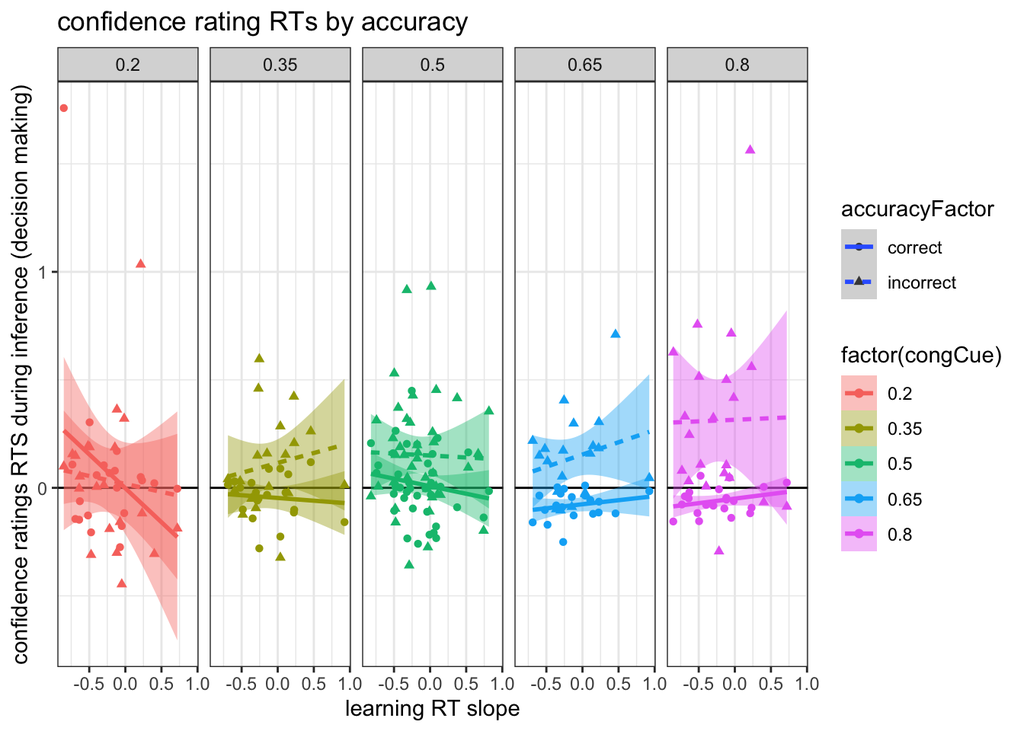

```r
df_inf %>%
  mutate(accuracyFactor = factor(accuracy, levels=c(1,0), labels=c('correct', 'incorrect'))) %>%
  group_by(subID, congCue, trueCue, trueCongruence, accuracyFactor) %>%
  summarise(meanZconfRT = mean(zconfRT, na.rm=T)) %>%
  left_join(., df_trueCue_trends, by=c('subID', 'trueCue')) %>%
  mutate(trueCue = factor(trueCue, levels=c(0.5, 0.65, 0.8))) %>%
  ggplot(., aes(x=scaledLogTrial.trend, y=meanZconfRT, color=factor(congCue), fill=factor(congCue))) + geom_hline(yintercept = 0) +
  facet_grid(~congCue) +
  theme_bw() + geom_point(aes(shape=accuracyFactor)) + stat_smooth(aes(linetype=accuracyFactor), method = 'lm') + labs(y = 'confidence ratings RTS during inference (decision making)', x = 'learning RT slope', title = 'confidence rating RTs by accuracy')
```

# SLIDING WINDOW ANALYSIS

### start by setting up dataframe & making some simple plots

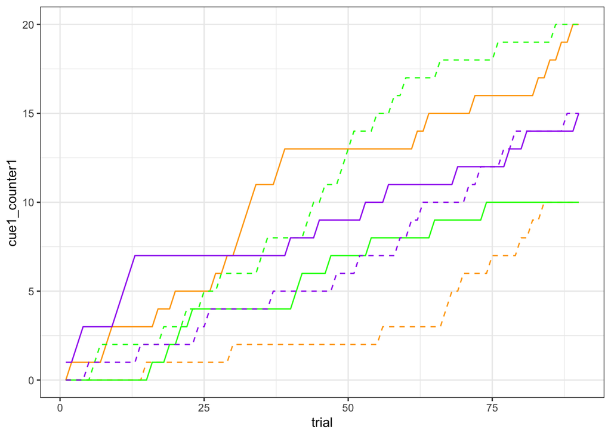

```r
# compute counter variables
df_learn_new <- df_learn %>%
  group_by(subID) %>%
  mutate(cue1_counter1 = cumsum(cueIdx==1 & imageIdx==1),
         cue1_counter2 = cumsum(cueIdx==1 & imageIdx==2),
         cue2_counter1 = cumsum(cueIdx==2 & imageIdx==1),
         cue2_counter2 = cumsum(cueIdx==2 & imageIdx==2),
         cue3_counter1 = cumsum(cueIdx==3 & imageIdx==1),
         cue3_counter2 = cumsum(cueIdx==3 & imageIdx==2))

# make an example plot
df_learn_new %>% filter(subID == 78) %>%
  ggplot(aes(x=trial)) +
  geom_line(aes(y=cue1_counter1), color='orange') + geom_line(aes(y=cue1_counter2), color='orange', linetype='dashed') +
  geom_line(aes(y=cue2_counter1), color='green') + geom_line(aes(y=cue2_counter2), color='green', linetype='dashed') +
  geom_line(aes(y=cue3_counter1), color='purple') + geom_line(aes(y=cue3_counter2), color='purple', linetype='dashed') + theme_bw()
```

```r
# compute number of matches between cue & image observed in each window of trials
window_size <- 5
window_bins <- seq(1, max(df_learn$trial), by=window_size)

df_learn_summary <- df_learn_new %>%
  group_by(subID) %>%
  mutate(window_bin = ceiling(trial / window_size)) %>%
  group_by(subID, cueIdx, window_bin) %>%
  summarise(nMatch_cue1 = max(cue1_counter1),
            nMismatch_cue1 = max(cue1_counter2),
            nMatch_cue2 = max(cue2_counter2),
            nMismatch_cue2 = max(cue2_counter1),
            img1_cue3 = max(cue3_counter1),
            img3_cue3 = max(cue3_counter2))
```

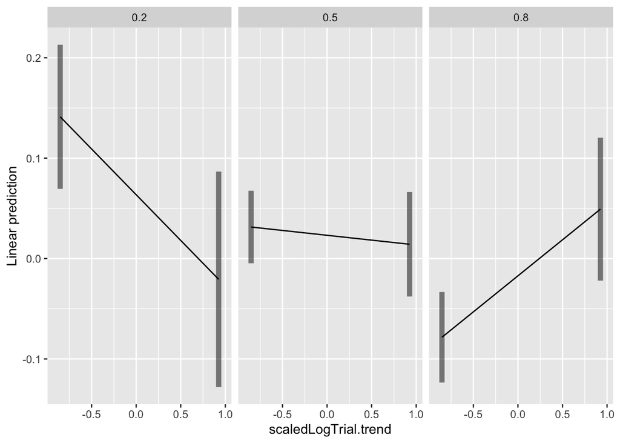

```r
# fit & plot linear model
df_inf %>% left_join(., df_trueCue_trends, by=c('subID', 'trueCue')) %>%
  lm(zlogRT ~ scaledLogTrial.trend*congCue, .) %>% #summary()
  emmip(., ~ scaledLogTrial.trend | congCue, var='congCue', CIs=T,
        at=list(scaledLogTrial.trend=range(df_trueCue_trends$scaledLogTrial.trend),
                                                                    congCue = c(0.2, 0.5, 0.8)))
```

```r
# emtrends for linear model
df_inf %>% left_join(., df_trueCue_trends, by=c('subID', 'trueCue')) %>%
  lm(zlogRT ~ scaledLogTrial.trend*congCue, .) %>%
  emtrends(eff ~ scaledLogTrial.trend, var = 'congCue',
           at=list(scaledLogTrial.trend=range(df_trueCue_trends$scaledLogTrial.trend),
                   congCue=c(0.8)))
```

```
## $emtrends
##  scaledLogTrial.trend congCue.trend     SE    df lower.CL upper.CL
##                -0.853        -0.366 0.0814 14989   -0.526   -0.206
##                 0.926         0.117 0.1270 14989   -0.133    0.366
##
## Confidence level used: 0.95
##
## $contrasts
##  contrast                                        estimate     SE    df t.ratio
##  (scaledLogTrial.trend-0.852741486839816) effect   -0.241 0.0946 14989  -2.549
##  scaledLogTrial.trend0.925641973264903 effect       0.241 0.0946 14989   2.549
##  p.value
##   0.0108
##   0.0108
##
## P value adjustment: fdr method for 2 tests
```

# aggregate datasets